# A3: Incarceration

### The Dataset

Who collected the data? - Bureau of Justice Statistics (BJS) data collections funded by Robert W. Wilson Charitable Trust

How was the data collected or generated?  
- The prison variables draw on the National Correction Reporting Program (NCRP) (collect individual data on admissions and releases since 1983) and directly from state departments of correction is NCRP data is not available or is unreliable. - The jails data draws on the Annual Survey of Jails (ASJ)(samples of counties since 1982), Census of Jails (COJ)(data on all counties since its first collection in 1970), and population and admissions variables from Death in Custody Reporting Program (DCRP) (facility-level jail population and admissions data 2000-2013). The ASJ and COJ are combines to create jail variables. -Separate variables are created using DCRP data. - Dataset also includes the population estimates collected by the US Census Bureau and the Centers for Disease Control and Prevention (CDC), geographic information from USDA. 32

Why was the data collected?  
- To provide detail on the sources and variables in the Incarceration Trends over time for the entire US. This involves county-level data on prison and jail incarceration and related measures as well.

How many observations (rows) are in your data?  
- 153811 rows

How many features (columns) are in the data?  
- 121 columns

What, if any, ethical questions or questions of power do you need to consider when working with this data?  
- Does black race or white race have a higher number of prisoners? Potential reasons?

What are possible limitations or problems with this data?  
- Overall there is not much of a problem working with the dataset since it already quite structured; however, I could still do some data cleaning before actually using the dataset to narrow my focus. Firstly, there are null outcomes for starting from column total_j1ail_pop till the end, this means the comparison between these groups will be affected by the range and how many null values it has. A lot of information lead to a lot of potential analysis so it might be a challenge for me to fully understand, come up with specific columns to work with, and think of potential chart/ maps to work on. So first, I have to clean records where it is null for consistency. On top of that, there are a lot of missing values starting from aapi_pop_15to64 till the end. I need to pay extra attention when working with these Race columns and always ignore NA values. - My plan to tackle this dataset is first to narrow down my focus the comparison of number of prisoners between races, with the elimination of null values. Having a plan will help me limit the problems of having too many ideas for a big dataset such as this one.

### Trends Over Time Chart

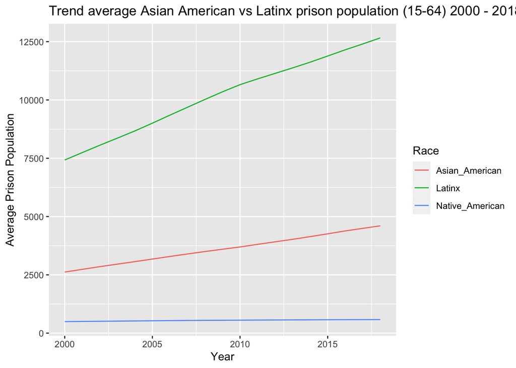

- This chart shows us how drastically the average number of prisoners increased throughout 20000-2018 and the difference between races: Asian American, Latinx, and Native American. I can see that there is a drastic difference between Latinx and the rest races, but I also notice that there is a quite low average number of Native American prisoners, there is no noticeable increases over a 18-year period for this race.Overall, I can tell by the chart that as the years progresses, more and more prisoners are in the US, which is a not so great. The purpose of this chart is to visualize how the average number of prisoners between these 3 races has changed throughout the years.

### Variable Comparison Chart

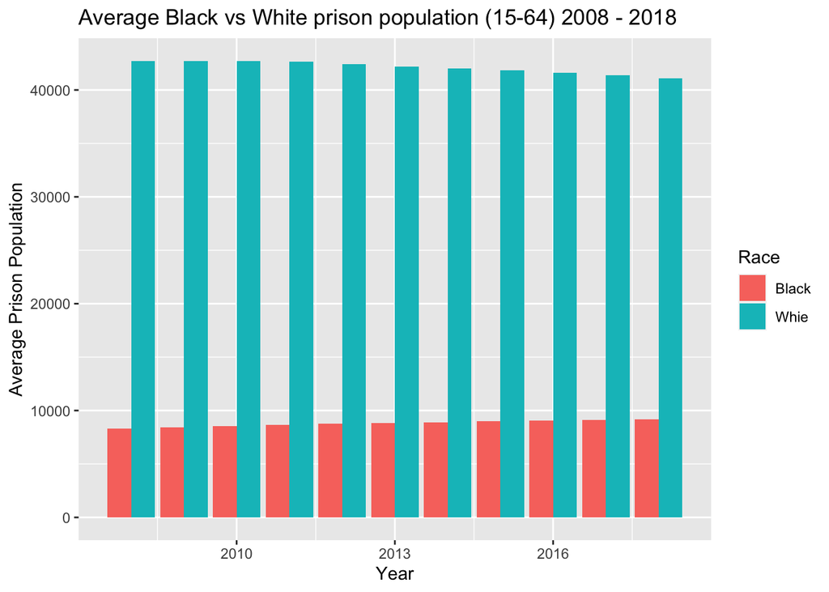

### Map

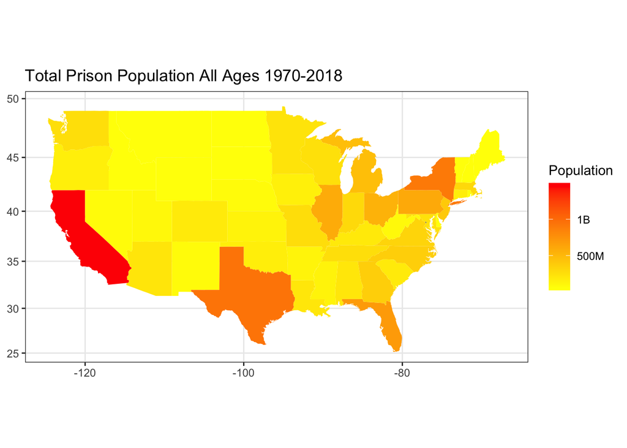